# nb_07_Salifort_Motors_project_Decision_Tree_Model

### Make Predictions - Decision Tree best_model_ - `model_dt1` - Test data

```python
# Make predictions on test data

model_dt1_best_model = model_dt1.best_estimator_ # Save the best parameters for later testing
y_pred_test = model_dt1_best_model.predict(X_test)
```

### Classification Report - `model_dt1` - Test data

```python
# def classification_report_summary(name:str, y_var:str, y_pred_var:str):

classification_report_summary(model_prefix+' - '+dataset+' - '+'test', y_test,y_pred_test)
```

```
Classification Report :  dt1 - ALLFeat - test
                           precision    recall  f1-score   support

Predicted would not leave       0.99      0.99      0.99      2321
    Predicted would leave       0.94      0.93      0.94       471

                 accuracy                           0.98      2792
                macro avg       0.96      0.96      0.96      2792
             weighted avg       0.98      0.98      0.98      2792

Recall        : 92.9936%
f1_score      : 93.5897%
Precision     : 94.1935%
Accuracy      : 97.8510%

───────────────────────────────────
Weighted Average
───────────────────────────────────
Recall        : 97.8510%
f1 Score      : 97.8455%
Precision     : 97.8416%
Support       : 2792

───────────────────────────────────
Prediction F1 score
───────────────────────────────────
Predict Leave : 93.5897%
Predict Stay  : 98.7091%
```

### Prepare and Save Results - Decision Tree - Predict - `model_dt1` - Test data

```python
#make_lr_results(model_name:str, model_object:str, X_var:str, y_var:str, y_pred_var:str)

# format prediction results into a dataframe
dt_pred_test_results = make_results(model_prefix+' - '+dataset+' - '+'test', model_dt1_best_model, X_test, y_test, y_pred_test)

# save the prediction results in Results.csv
dt_pred_test_results.to_csv("Results.csv", mode='a', index=True, header=False)
```

## Performance Results & Comparisons - `model_dt1` - Test data

### Display Results - Test - `model_dt1` - Test data

```python
print(dt_pred_test_results) # Display results of the prediction
display_results() # Display contents of Results.csv
```

```
                  Model  Precision  Recall    F1  Accuracy   AUC  Predict Leave  Predict Stay
0  dt1 - ALLFeat - test      0.978   0.979 0.978     0.979 0.979          0.936         0.987
```

|  | Model | Precision | Recall | F1 | Accuracy | AUC | Predict Leave | Predict Stay |
| --- | --- | --- | --- | --- | --- | --- | --- | --- |
| 5 | dt1 - ALLFeat - test | 0.978 | 0.979 | 0.978 | 0.979 | 0.979 | 0.936 | 0.987 |
| 4 | dt1 - ALLFeat - GS train | 0.951 | 0.914 | 0.932 | 0.977 | 0.974 | NaN | NaN |
| 1 | lr1 - ALLFeat - train | 0.796 | 0.827 | 0.804 | 0.827 | 0.892 | 0.328 | 0.900 |
| 3 | lr2 - NOdept - train | 0.793 | 0.825 | 0.802 | 0.825 | 0.892 | 0.318 | 0.900 |
| 0 | lr1 - ALLFeat - test | 0.794 | 0.822 | 0.803 | 0.822 | 0.882 | 0.341 | 0.897 |
| 2 | lr2 - NOdept - test | 0.795 | 0.823 | 0.804 | 0.823 | 0.882 | 0.343 | 0.898 |

### Make Predictions - Decision Tree best_estimator_ - `model_dt1` - Train data

```python
# Make predictions on train data
print("Started / Last Run =", dt.now().strftime("%Y-%m-%d %H:%M:%S"))

model_dt1_best_model = model_dt1.best_estimator_ # Save the best parameters for later testing
y_pred_train = model_dt1_best_model.predict(X_train)
```

```
Started / Last Run = 2023-12-04 12:02:06
```

### Classification Report - `model_dt1` - Train data

```python
# def classification_report_summary(name:str, y_var:str, y_pred_var:str):

classification_report_summary(model_prefix+' - '+dataset+' - '+'train', y_train,y_pred_train)
```

```
Classification Report :  dt1 - ALLFeat - train
                           precision    recall  f1-score   support

Predicted would not leave       0.98      0.99      0.99      6964
    Predicted would leave       0.96      0.92      0.94      1411

                 accuracy                           0.98      8375
                macro avg       0.97      0.95      0.96      8375
             weighted avg       0.98      0.98      0.98      8375

Recall        : 91.5663%
f1_score      : 93.5215%
Precision     : 95.5621%
Accuracy      : 97.8627%

───────────────────────────────────
Weighted Average
───────────────────────────────────
Recall        : 97.8627%
f1 Score      : 97.8444%
Precision     : 97.8434%
Support       : 8375

───────────────────────────────────
Prediction F1 score
───────────────────────────────────
Predict Leave : 93.5215%
Predict Stay  : 98.7202%
```

### Prepare and Save Results - Decision Tree - Predict - `model_dt1` - Train data

```python
#make_lr_results(model_name:str, model_object:str, X_var:str, y_var:str, y_pred_var:str)

# format prediction results into a dataframe
dt_pred_test_results = make_results(model_prefix+' - '+dataset+' - '+'train', model_dt1_best_model, X_train, y_train, y_pred_train)

# Save dataframe into results.csv, no header
dt_pred_test_results.to_csv("Results.csv", mode='a', index=True, header=False) # save the prediction results in Results.csv
```

## Performance Results & Comparisons - `model_dt1` - Train data

### Display Results

```python
print(dt_pred_test_results) # Display results of the prediction
pd.options.display.float_format = '{:.3f}'.format
display_results() # Display contents of Results.csv
```

```
                   Model  Precision  Recall    F1  Accuracy   AUC  Predict Leave  Predict Stay
0  dt1 - ALLFeat - train      0.978   0.979 0.978     0.979 0.979          0.935         0.987
```

|  | Model | Precision | Recall | F1 | Accuracy | AUC | Predict Leave | Predict Stay |
| --- | --- | --- | --- | --- | --- | --- | --- | --- |
| 5 | dt1 - ALLFeat - test | 0.978 | 0.979 | 0.978 | 0.979 | 0.979 | 0.936 | 0.987 |
| 6 | dt1 - ALLFeat - train | 0.978 | 0.979 | 0.978 | 0.979 | 0.979 | 0.935 | 0.987 |
| 4 | dt1 - ALLFeat - GS train | 0.951 | 0.914 | 0.932 | 0.977 | 0.974 | NaN | NaN |
| 1 | lr1 - ALLFeat - train | 0.796 | 0.827 | 0.804 | 0.827 | 0.892 | 0.328 | 0.900 |
| 3 | lr2 - NOdept - train | 0.793 | 0.825 | 0.802 | 0.825 | 0.892 | 0.318 | 0.900 |
| 0 | lr1 - ALLFeat - test | 0.794 | 0.822 | 0.803 | 0.822 | 0.882 | 0.341 | 0.897 |
| 2 | lr2 - NOdept - test | 0.795 | 0.823 | 0.804 | 0.823 | 0.882 | 0.343 | 0.898 |

### Decision Tree Plot - Visualise splits - `model_dt1`

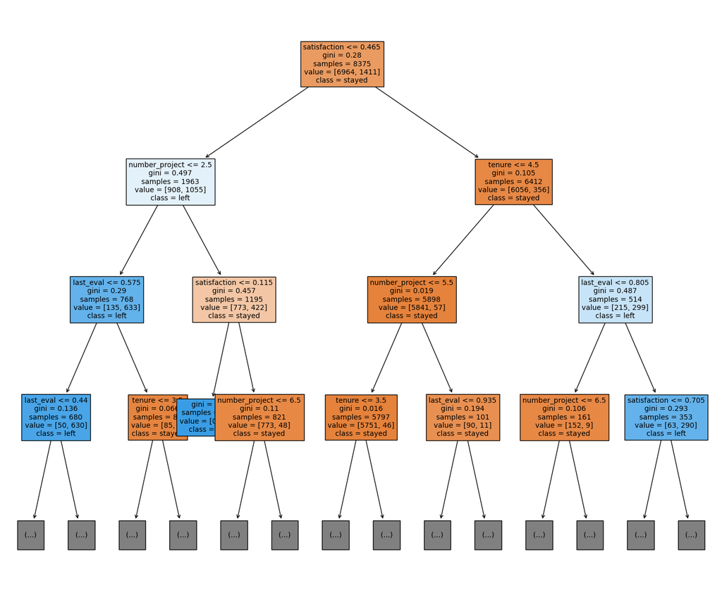

```python
plt.figure(figsize=(18,15))
plot_tree(model_dt1_best_model,max_depth=3, fontsize=10, feature_names=X_test.columns, class_names={0:'stayed',1:'left'}, filled=True);
plt.show()
```

## Construct Model - Decision Tree - No Departments - `model_dt2`

### Import Data - `model_dt2` - No Departments

Two datasets for model performance comparison, :

`Dept` appears to have low correlation across the dataset and I'm curious how much the models are influenced with low correlation features. It turns out that low correlation features have little impact on model performance. which is no surprise really!

#### Code flags:

**model_prefix** = text indicating which ML model is being used, added to the model description during csv save to Results.csv

**dataset** = Text indicating which dataset is being used, added to the model description during csv save to Results.csv

**rerun** = flag to identify the first run of the model comparisons and write a NEW Results.csv file. 0 = first run and a new file will be created with headers / 1 = Continuation, Results will be appended to the file.

refit = flag to identify id the model needs fitting. Not a big issue for decision tree

```python
df2 = pd.read_csv(load_path + "data_cleaned_NoOl_FE_NoDept.csv", index_col = False) # Feature engineering on salary, avg_mnth_hrs, outliers removed, departments removed

print("df2 - Feature engineering on salary, avg_mnth_hrs, dept REMOVED, outliers removed\n")


df2.sort_index(axis=1, inplace=True)

# model_prefix : Str = prefix for results.csv added to dataset
model_prefix     = 'dt2'

# dataset : Str = dataset name for results.csv
dataset          = 'NOdept'

# rerun : int =  Flag to set 1 = append to Results.csv / 0 = Overwrite with new file
rerun            = 1

refit            = 0 # run refit, not a big issue for Decision tree.


# Display dataframe columns
df2.columns
```

```
df2 - Feature engineering on salary, avg_mnth_hrs, dept REMOVED, outliers removed
```

```
Index(['last_eval', 'left', 'number_project', 'overworked', 'promotion', 'salary', 'satisfaction', 'tenure'], dtype='object')
```

### Prepare data for modelling - `model_dt2`

```python
model_data2 = df2.copy()
```

### Isolate Outcome and Feature Variables - `model_dt2`

```python
# Isolate the outcome and feature variables

# Isolate the outcome variable 'left' is a binary value where true = employee left employment
Y2 = model_data2['left']

# Select & Isolate the feature variables and drop the outcome variable
X2 = model_data2.copy()
X2 = X2.drop('left', axis = 1)
```

### Train Test split data - `model_dt2`

```python
# Prepare training and test data
X_train2, X_test2, y_train2, y_test2 = train_test_split(X2,Y2, test_size=0.25, stratify=Y, random_state=0)
```

### Instantiate Model - Decision Tree - GridSearch - `model_dt2` - Train data

```python
# Instantiate model
tree2 = DecisionTreeClassifier(random_state=0)

# Assign a dictionary of hyperparameters to search over
cv_params = {'max_depth':[4, 6, 8, None],
             'min_samples_leaf': [2, 5, 1],
             'min_samples_split': [2, 4, 6]
             }

# Assign a dictionary of scoring metrics to capture
scoring = ('accuracy', 'precision', 'recall', 'f1', 'roc_auc')

# Instantiate GridSearch
model_dt2 = GridSearchCV(tree2, cv_params, scoring=scoring, cv=4, refit='roc_auc')
```

### Fit Data - `model_dt2` - Train data

```python
%%time
model_dt2.fit(X_train2, y_train2)
beepr()
```

```
CPU times: user 4.44 s, sys: 5.76 ms, total: 4.45 s
Wall time: 6.99 s
```

### Read / Write Pickle Model - `model_dt2`

```python
## Write pickle

if refit == 1: # refit = 1 run the fit and save the model
    write_pickle(model_path, model_dt2, 'hr_dt2-'+'NOdept')

# Read in pickle
if refit == 0: # refit = 0 load model, don't  fit the data
    model_xg2 = read_pickle(model_path, 'hr_dt2-'+'NOdept')
```

### Get & Display GridSearch best_estimator results - `model_dt2` - Train data

```python
# Get the parameters of the best-performing model
print(model_prefix+' - '+dataset+' - '+'test\n')
print("Best Parameters : ", model_dt2.best_params_)

# Get the average f1 score of the best-performing model
print("Best Score      : {:.4f}".format(model_dt2.best_score_))

# Get the best estimators of the parameters
print("Best Estimator  : ", model_dt2.best_estimator_)
```

```
dt2 - NOdept - test

Best Parameters :  {'max_depth': 4, 'min_samples_leaf': 1, 'min_samples_split': 2}
Best Score      : 0.9737
Best Estimator  :  DecisionTreeClassifier(max_depth=4, random_state=0)
```

### Prepare and Save Results - `model_dt2` - Train data

```python
model_dt2_cv_results = format_GS_results(model_prefix+' - '+dataset+' - '+'GS train', model_dt2, 'auc')
model_dt2_cv_results.to_csv("Results.csv", mode='a', index=True, header=False)
```

## Performance Results & Comparisons - `model_dt2` - Train data

### Display Results - `model_dt2` - Train data

```python
pd.options.display.float_format = '{:.3f}'.format
print(model_dt2_cv_results,"\n")
display_results()
```

```
                     Model  Precision  Recall    F1  Accuracy   AUC
0  dt2 - NOdept - GS train      0.951   0.914 0.932     0.977 0.974
```

|  | Model | Precision | Recall | F1 | Accuracy | AUC | Predict Leave | Predict Stay |
| --- | --- | --- | --- | --- | --- | --- | --- | --- |
| 5 | dt1 - ALLFeat - test | 0.978 | 0.979 | 0.978 | 0.979 | 0.979 | 0.936 | 0.987 |
| 6 | dt1 - ALLFeat - train | 0.978 | 0.979 | 0.978 | 0.979 | 0.979 | 0.935 | 0.987 |
| 7 | dt2 - NOdept - GS train | 0.951 | 0.914 | 0.932 | 0.977 | 0.974 | NaN | NaN |
| 4 | dt1 - ALLFeat - GS train | 0.951 | 0.914 | 0.932 | 0.977 | 0.974 | NaN | NaN |
| 1 | lr1 - ALLFeat - train | 0.796 | 0.827 | 0.804 | 0.827 | 0.892 | 0.328 | 0.900 |
| 3 | lr2 - NOdept - train | 0.793 | 0.825 | 0.802 | 0.825 | 0.892 | 0.318 | 0.900 |
| 0 | lr1 - ALLFeat - test | 0.794 | 0.822 | 0.803 | 0.822 | 0.882 | 0.341 | 0.897 |
| 2 | lr2 - NOdept - test | 0.795 | 0.823 | 0.804 | 0.823 | 0.882 | 0.343 | 0.898 |

### Make Predictions - Decision Tree best_model_ - `model_dt2` - Test data

```python
# Make predictions on test data

model_dt2_best_model = model_dt2.best_estimator_ # Save the best parameters for later testing
y_pred_test2 = model_dt2_best_model.predict(X_test2)
```

### Classification Report - `model_dt2` - Test data

```python
# def classification_report_summary(name:str, y_var:str, y_pred_var:str):

classification_report_summary(model_prefix+' - '+dataset+' - '+'test', y_test2,y_pred_test2)
```

```
Classification Report :  dt2 - NOdept - test
                           precision    recall  f1-score   support

Predicted would not leave       0.99      0.99      0.99      2321
    Predicted would leave       0.94      0.93      0.94       471

                 accuracy                           0.98      2792
                macro avg       0.96      0.96      0.96      2792
             weighted avg       0.98      0.98      0.98      2792

Recall        : 92.9936%
f1_score      : 93.5897%
Precision     : 94.1935%
Accuracy      : 97.8510%

───────────────────────────────────
Weighted Average
───────────────────────────────────
Recall        : 97.8510%
f1 Score      : 97.8455%
Precision     : 97.8416%
Support       : 2792

───────────────────────────────────
Prediction F1 score
───────────────────────────────────
Predict Leave : 93.5897%
Predict Stay  : 98.7091%
```

### Prepare and Save Results - Decision Tree - Predict - `model_dt2` - Test data

```python
dt_pred_test_results2 = make_results(model_prefix+' - '+dataset+' - '+'test', model_dt2_best_model, X_test2, y_test2, y_pred_test2) # format prediction results into a dataframe
dt_pred_test_results2.to_csv("Results.csv", mode='a', index=True, header=False) # save the prediction results in Results.csv
```

## Performance Results & Comparisons - `model_dt2` - Test data

### Display Results - `model_dt2` - Test data

```python
print(dt_pred_test_results2) # Display results of the prediction
display_results() # Display contents of Results.csv
```

```
                 Model  Precision  Recall    F1  Accuracy   AUC  Predict Leave  Predict Stay
0  dt2 - NOdept - test      0.978   0.979 0.978     0.979 0.979          0.936         0.987
```

|  | Model | Precision | Recall | F1 | Accuracy | AUC | Predict Leave | Predict Stay |
| --- | --- | --- | --- | --- | --- | --- | --- | --- |
| 5 | dt1 - ALLFeat - test | 0.978 | 0.979 | 0.978 | 0.979 | 0.979 | 0.936 | 0.987 |
| 8 | dt2 - NOdept - test | 0.978 | 0.979 | 0.978 | 0.979 | 0.979 | 0.936 | 0.987 |
| 6 | dt1 - ALLFeat - train | 0.978 | 0.979 | 0.978 | 0.979 | 0.979 | 0.935 | 0.987 |
| 7 | dt2 - NOdept - GS train | 0.951 | 0.914 | 0.932 | 0.977 | 0.974 | NaN | NaN |
| 4 | dt1 - ALLFeat - GS train | 0.951 | 0.914 | 0.932 | 0.977 | 0.974 | NaN | NaN |
| 1 | lr1 - ALLFeat - train | 0.796 | 0.827 | 0.804 | 0.827 | 0.892 | 0.328 | 0.900 |
| 3 | lr2 - NOdept - train | 0.793 | 0.825 | 0.802 | 0.825 | 0.892 | 0.318 | 0.900 |
| 0 | lr1 - ALLFeat - test | 0.794 | 0.822 | 0.803 | 0.822 | 0.882 | 0.341 | 0.897 |
| 2 | lr2 - NOdept - test | 0.795 | 0.823 | 0.804 | 0.823 | 0.882 | 0.343 | 0.898 |

### Make Predictions - Decision Tree best_estimator_ - `model_dt2` - Train data

```python
# Make predictions on train data
print("Current Time =", dt.now().strftime("%H:%M:%S"))

dt_best_model2 = model_dt2.best_estimator_ # Save the best parameters for later testing
y_pred_train2 = model_dt2_best_model.predict(X_train2)
```

```
Current Time = 12:02:17
```

### Classification Report - `model_dt2` - Train data

```python
# def classification_report_summary(name:str, y_var:str, y_pred_var:str):

classification_report_summary(model_prefix+' - '+dataset+' - '+'train', y_train2,y_pred_train2)
```

```
Classification Report :  dt2 - NOdept - train
                           precision    recall  f1-score   support

Predicted would not leave       0.98      0.99      0.99      6964
    Predicted would leave       0.96      0.92      0.94      1411

                 accuracy                           0.98      8375
                macro avg       0.97      0.95      0.96      8375
             weighted avg       0.98      0.98      0.98      8375

Recall        : 91.5663%
f1_score      : 93.5215%
Precision     : 95.5621%
Accuracy      : 97.8627%

───────────────────────────────────
Weighted Average
───────────────────────────────────
Recall        : 97.8627%
f1 Score      : 97.8444%
Precision     : 97.8434%
Support       : 8375

───────────────────────────────────
Prediction F1 score
───────────────────────────────────
Predict Leave : 93.5215%
Predict Stay  : 98.7202%
```

### Prepare and Save Results - Decision Tree - Predict - `model_dt2` - Train data

```python
#make_lr_results(model_name:str, model_object:str, X_var:str, y_var:str, y_pred_var:str)

dt_pred_test_results2 = make_results(model_prefix+' - '+dataset+' - '+'train', model_dt2_best_model, X_train2, y_train2, y_pred_train2) # format prediction results into a dataframe
dt_pred_test_results2.to_csv("Results.csv", mode='a', index=True, header=False) # save the prediction results in Results.csv
```